# Determinging the Number of Clusters

Determining the optimal number of clusters is one of the most important prerequisites for certain classes of clustering algorithms such as k-means clustering. Such algorithms require the user to specify the number of clusters manually. There are several approaches for determing the number of clusters. We will see two such important methods.

1. Elbow Method
2. Silhouette Method

## Elbow Method

The Elbow method looks at the total Within Cluster Sum Of Squares(WSS) as a function of the number of clusters. The optimal number of clusters will be the one after which any further addition of another cluster doesn’t improve the total WSS for all clusters put together or significantly so.

In order to use the elbow method, try k-means cluster for n_clusters ranging from say 1 to N (say 10) and plot the total WSS against the number of clusters. In the plot where the elbow (or knee or simply the bent) is found, the WSS flattens as we add more clusters. Such a point gives us the optimal number of clusters.

## Exercise:

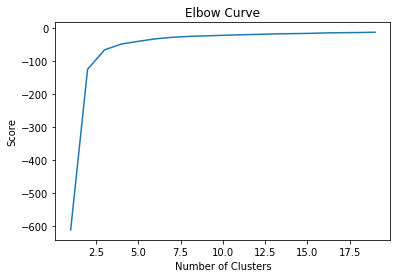

```python
from sklearn.cluster import KMeans
from sklearn.cross_validation import train_test_split
import matplotlib.pyplot as plt

import pandas as pd

iris = pd.read_csv('https://raw.githubusercontent.com/plotly/datasets/master/iris.csv')

features = ['SepalLength', 'SepalWidth', 'PetalLength', 'PetalWidth']
iris_train, iris_test = train_test_split(iris, train_size=0.9)
X = iris[features]
n_clusters = range(1, 20)
kmeans = [KMeans(n_clusters=i, init='k-means++', n_init=10, max_iter=300, tol=0.0001, precompute_distances='auto', verbose=0, random_state=None, copy_x=True, n_jobs=1)
          for i in n_clusters]
score = [kmeans[i].fit(iris_train[features]).score(iris_train[features]) for i in range(len(kmeans))]
plt.plot(n_clusters,score)
plt.xlabel('Number of Clusters')
plt.ylabel('Score')
plt.title('Elbow Curve')
plt.show()
```

### Solution

Hit run to execute the above code.

In the above plot, you can observe the knee starts between 3 and 4. A larger bend is around 3. Hence k=3 would be the optimal number of clusters.

## Silhouette Method

The silhouette method computes the average silhouette score of observations for different values of n_clusters. The optimal number of clusters k is the one that maximizes the average silhouette over a range of possible values for k (n_clusters). This algorithm is similar to the elbow method, but differs in the computation of silhuette score.

The Silhouette Coefficient is a metric to estimate the optimum number of clusters. It uses average intra-cluster distance and average nearest-cluster distance for each sample. Higher the value of the score, the better the estimate. Typically the silhoutte scores go high and then fall peaking at an optimum cluster number. The values lie between -1.0 and 1.0.

```
k_clusters = []
sil_coeffecients = []

for n_cluster in range(2,11):
    kmeans = KMeans(n_clusters = n_cluster).fit(X)
    label = kmeans.labels_
    sil_coeff = silhouette_score(X, label)
    print("For n_clusters={}, Silhouette Coefficient = {}".format(n_cluster, sil_coeff))
    sil_coeffecients.append(sil_coeff)
    k_clusters.append(n_cluster)

plt.plot(k_clusters, sil_coeffecients)
plt.ylabel('Silhouette Coefficient'), plt.xlabel('No. of Clusters')
plt.show()
```

[figure not shown]

## Exercise

- From the above plot retrieve the optimum number of clusters and assign it to the variable k_best.
- Print it out.

```
For n_clusters=2, Silhouette Coefficient = 0.6808136202936816
For n_clusters=3, Silhouette Coefficient = 0.5525919445499757
For n_clusters=4, Silhouette Coefficient = 0.4978256901095472
For n_clusters=5, Silhouette Coefficient = 0.4885175508886279
For n_clusters=6, Silhouette Coefficient = 0.37121805054590074
For n_clusters=7, Silhouette Coefficient = 0.3491743021437674
For n_clusters=8, Silhouette Coefficient = 0.3631969081840424
For n_clusters=9, Silhouette Coefficient = 0.3336841980997024
For n_clusters=10, Silhouette Coefficient = 0.3433148637625927
```

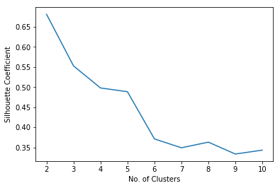

```
Optimum Number of Clusters: 2
```

```python
from sklearn.metrics import silhouette_score

k_clusters = []
sil_coeffecients = []

for n_cluster in range(2,11):
    kmeans = KMeans(n_clusters = n_cluster).fit(X)
    label = kmeans.labels_
    sil_coeff = silhouette_score(X, label)
    print("For n_clusters={}, Silhouette Coefficient = {}".format(n_cluster, sil_coeff))
    sil_coeffecients.append(sil_coeff)
    k_clusters.append(n_cluster)

plt.plot(k_clusters, sil_coeffecients)
plt.ylabel('Silhouette Coefficient'), plt.xlabel('No. of Clusters')
plt.show()

sil_best = max(sil_coeffecients)
k_best_index = sil_coeffecients.index(sil_best)
k_best = k_clusters[k_best_index]
print("Optimum Number of Clusters:", k_best)
```

### Solution

```
sil_best = max(sil_coeffecients)
k_best_index = sil_coeffecients.index(sil_best)
k_best = k_clusters[k_best_index]
print("Optimum Number of Clusters:", k_best)
```

From the above it seems 2 clusters is the optimal. But is it accurate? Let's visualize the clusters against the shilouette scores. But this time let us use make_blob dataset from sklearn.

### Exercise

Write code to compute silhouette score for the sklearn.make_blobs dataset. Create the plot for n_clusters ranging from 2 to 6. Plot the silhouette_scores and determine the optimal number of clusters.

```
Automatically created module for IPython interactive environment
For n_clusters = 2 The average silhouette_score is : 0.7049787496083262
For n_clusters = 3 The average silhouette_score is : 0.5882004012129721
For n_clusters = 4 The average silhouette_score is : 0.6505186632729437
For n_clusters = 5 The average silhouette_score is : 0.56376469026194
For n_clusters = 6 The average silhouette_score is : 0.4504666294372765
```

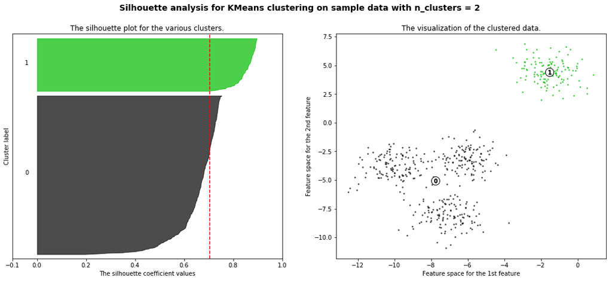

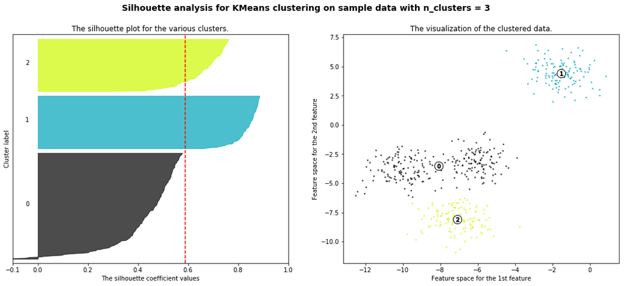

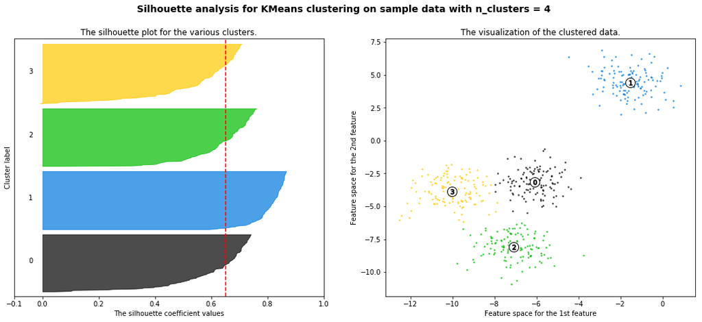

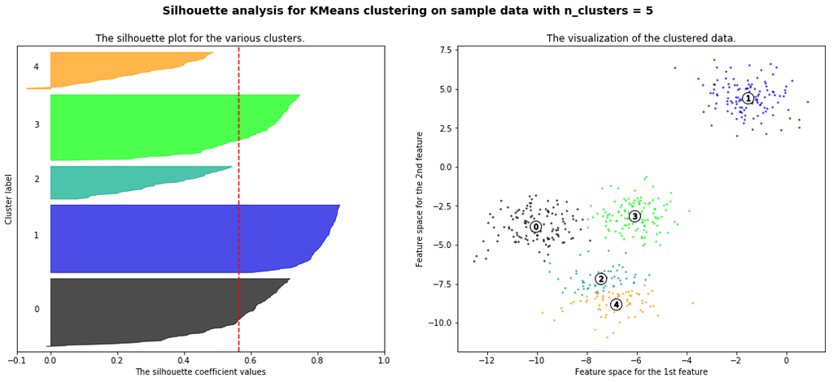

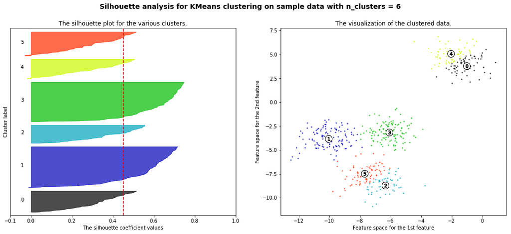

```python
from sklearn.datasets import make_blobs
from sklearn.cluster import KMeans
from sklearn.metrics import silhouette_samples, silhouette_score

import matplotlib.pyplot as plt
import matplotlib.cm as cm
import numpy as np

print(__doc__)

# Generating the sample data from make_blobs
# This particular setting has one distinct cluster and 3 clusters placed close
# together.
X, y = make_blobs(n_samples=500,
                  n_features=2,
                  centers=4,
                  cluster_std=1,
                  center_box=(-10.0, 10.0),
                  shuffle=True,
                  random_state=1)  # For reproducibility

range_n_clusters = [2, 3, 4, 5, 6]

for n_clusters in range_n_clusters:
    # Create a subplot with 1 row and 2 columns
    fig, (ax1, ax2) = plt.subplots(1, 2)
    fig.set_size_inches(18, 7)

    # The 1st subplot is the silhouette plot
    # The silhouette coefficient can range from -1, 1 but in this example all
    # lie within [-0.1, 1]
    ax1.set_xlim([-0.1, 1])
    # The (n_clusters+1)*10 is for inserting blank space between silhouette
    # plots of individual clusters, to demarcate them clearly.
    ax1.set_ylim([0, len(X) + (n_clusters + 1) * 10])

    # Initialize the clusterer with n_clusters value and a random generator
    # seed of 10 for reproducibility.
    clusterer = KMeans(n_clusters=n_clusters, random_state=10)
    cluster_labels = clusterer.fit_predict(X)

    # The silhouette_score gives the average value for all the samples.
    # This gives a perspective into the density and separation of the formed
    # clusters
    silhouette_avg = silhouette_score(X, cluster_labels)
    print("For n_clusters =", n_clusters,
          "The average silhouette_score is :", silhouette_avg)

    # Compute the silhouette scores for each sample
    sample_silhouette_values = silhouette_samples(X, cluster_labels)

    y_lower = 10
    for i in range(n_clusters):
        # Aggregate the silhouette scores for samples belonging to
        # cluster i, and sort them
        ith_cluster_silhouette_values = \
            sample_silhouette_values[cluster_labels == i]

        ith_cluster_silhouette_values.sort()

        size_cluster_i = ith_cluster_silhouette_values.shape[0]
        y_upper = y_lower + size_cluster_i

        color = cm.nipy_spectral(float(i) / n_clusters)
        ax1.fill_betweenx(np.arange(y_lower, y_upper),
                          0, ith_cluster_silhouette_values,
                          facecolor=color, edgecolor=color, alpha=0.7)

        # Label the silhouette plots with their cluster numbers at the middle
        ax1.text(-0.05, y_lower + 0.5 * size_cluster_i, str(i))

        # Compute the new y_lower for next plot
        y_lower = y_upper + 10  # 10 for the 0 samples

    ax1.set_title("The silhouette plot for the various clusters.")
    ax1.set_xlabel("The silhouette coefficient values")
    ax1.set_ylabel("Cluster label")

    # The vertical line for average silhouette score of all the values
    ax1.axvline(x=silhouette_avg, color="red", linestyle="--")

    ax1.set_yticks([])  # Clear the yaxis labels / ticks
    ax1.set_xticks([-0.1, 0, 0.2, 0.4, 0.6, 0.8, 1])

    # 2nd Plot showing the actual clusters formed
    colors = cm.nipy_spectral(cluster_labels.astype(float) / n_clusters)
    ax2.scatter(X[:, 0], X[:, 1], marker='.', s=30, lw=0, alpha=0.7,
                c=colors, edgecolor='k')

    # Labeling the clusters
    centers = clusterer.cluster_centers_
    # Draw white circles at cluster centers
    ax2.scatter(centers[:, 0], centers[:, 1], marker='o',
                c="white", alpha=1, s=200, edgecolor='k')

    for i, c in enumerate(centers):
        ax2.scatter(c[0], c[1], marker='$%d$' % i, alpha=1,
                    s=50, edgecolor='k')

    ax2.set_title("The visualization of the clustered data.")
    ax2.set_xlabel("Feature space for the 1st feature")
    ax2.set_ylabel("Feature space for the 2nd feature")

    plt.suptitle(("Silhouette analysis for KMeans clustering on sample data "
                  "with n_clusters = %d" % n_clusters),
                 fontsize=14, fontweight='bold')

plt.show()
```

### Solution

Hit Run

From the above it is clear that though 2 & 4 for n_clusters seems good from silhouette scores, there are ideally 4 clusters. That is optimal value of k is 4.

```python
#No Exercise
```

End of Section.